# Reproducible Research: Peer Assessment 1

## Loading and preprocessing the data.

```r
mydata <- read.csv("activity.csv")
str(mydata)
```

```
## 'data.frame':    17568 obs. of  3 variables:
##  $ steps   : int  NA NA NA NA NA NA NA NA NA NA ...
##  $ date    : Factor w/ 61 levels "2012-10-01","2012-10-02",..: 1 1 1 1 1 1 1 1 1 1 ...
##  $ interval: int  0 5 10 15 20 25 30 35 40 45 ...
```

## What is mean total number of steps taken per day?

Calculate the total number of steps taken per day. The NAs are ignored.

```r
day.total <- lapply(split(mydata$steps, mydata$date), sum, na.rm = TRUE)
```

Make a histogram of the total number of steps taken each day.

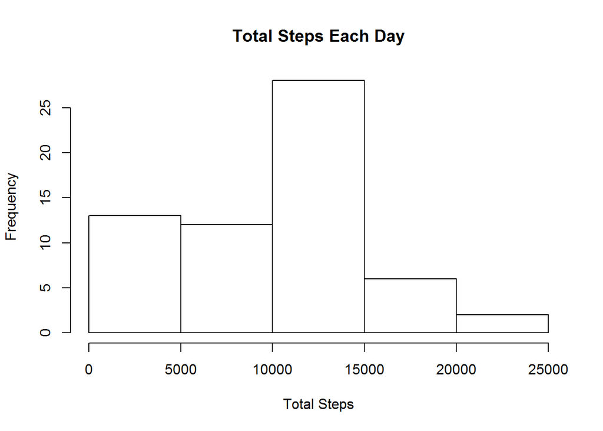

```r
library(reshape)
day.total <- melt(day.total)
day.total <- rename(day.total, c(L1 = "date"))
hist(day.total$value, main = "Total Steps Each Day", xlab = "Total Steps")
```

Calculate and report the mean and median of the total number of steps taken per day.

- the mean of the total number of steps taken per day

```r
mean(day.total$value)
```

```
## [1] 9354.23
```

- the median of the total number of steps taken per day

```r
median(day.total$value)
```

```
## [1] 10395
```

## What is the average daily activity pattern?

Make a time series plot (i.e. type = “l”) of the 5-minute interval (x-axis) and the average number of steps taken, averaged across all days (y-axis). The NAs are ignored.

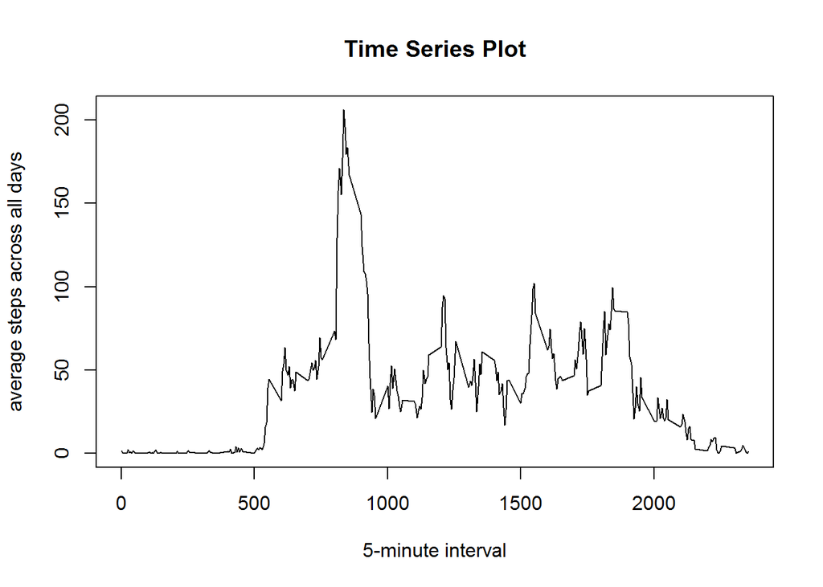

```r
time.series <- lapply(split(mydata$steps, mydata$interval), mean, na.rm = TRUE)
time.series <- melt(time.series)
time.series <- rename(time.series, c(L1 = "interval"))
plot(time.series$interval, time.series$value, type = "l", xlab = "5-minute interval", ylab = "average steps across all days", main = "Time Series Plot")
```

Which 5-minute interval, on average across all the days in the dataset, contains the maximum number of steps?

```r
time.series[which.max(time.series$value), "interval"]
```

```
## [1] "835"
```